# K Means Clustering Using R

Etana Disasa

10/24/2019

# Introduction

##### This week, we are using K-means to cluster a dataset. We will see how we can find the optimal k value in order to cluster our dataset. We will also do visualization of the clusters with visible centroids.

# Methods

## Acquiring Data

```r
MyData <- read.csv(file = "water-treatment.data", header = FALSE)
str(MyData)
```

```
## 'data.frame':    527 obs. of  39 variables:
##  $ V1 : Factor w/ 527 levels "D-1/1/90","D-1/1/91",..: 8 199 429 445 463 481 499 517 41 58 ...
##  $ V2 : Factor w/ 504 levels "?","10050","15519",..: 422 332 101 221 284 321 374 258 41 335 ...
##  $ V3 : Factor w/ 173 levels "?","0.10","0.12",..: 68 118 145 128 68 118 154 145 107 96 ...
##  $ V4 : num  7.8 7.7 7.6 7.9 8 7.8 7.8 7.7 7.7 7.8 ...
##  $ V5 : Factor w/ 205 levels "?","100","102",..: 1 1 1 95 128 92 1 104 96 62 ...
##  $ V6 : Factor w/ 289 levels "?","105","126",..: 144 171 233 258 213 119 247 207 177 219 ...
##  $ V7 : Factor w/ 142 levels "?","1004","1016",..: 34 59 44 47 39 44 83 112 48 51 ...
##  $ V8 : Factor w/ 275 levels "?","13.2","17.8",..: 179 203 210 173 166 199 160 40 202 201 ...
##  $ V9 : Factor w/ 60 levels "?","0.4","0.7",..: 38 52 30 38 35 38 42 50 38 42 ...
##  $ V10: int  2110 2660 1666 2430 2110 1644 1603 1613 1249 1865 ...
##  $ V11: num  7.9 7.7 7.7 7.8 7.9 7.8 7.8 7.6 7.7 7.8 ...
##  $ V12: Factor w/ 226 levels "?","100","101",..: 1 1 1 129 1 1 1 1 100 102 ...
##  $ V13: int  228 244 220 268 236 248 320 304 220 248 ...
##  $ V14: Factor w/ 285 levels "?","13.7","17.7",..: 226 265 245 248 120 188 199 95 152 188 ...
```

[output cut: 25 more lines]

##### There are several factor variable that need to be converted to numeric. There are also variables with several missing info/observations. Therefore, we will have to take those out.

```r
MyData[MyData == "?"] <- NA
str(MyData)
```

```
## 'data.frame':    527 obs. of  39 variables:
##  $ V1 : Factor w/ 527 levels "D-1/1/90","D-1/1/91",..: 8 199 429 445 463 481 499 517 41 58 ...
##  $ V2 : Factor w/ 504 levels "?","10050","15519",..: 422 332 101 221 284 321 374 258 41 335 ...
##  $ V3 : Factor w/ 173 levels "?","0.10","0.12",..: 68 118 145 128 68 118 154 145 107 96 ...
##  $ V4 : num  7.8 7.7 7.6 7.9 8 7.8 7.8 7.7 7.7 7.8 ...
##  $ V5 : Factor w/ 205 levels "?","100","102",..: NA NA NA 95 128 92 NA 104 96 62 ...
##  $ V6 : Factor w/ 289 levels "?","105","126",..: 144 171 233 258 213 119 247 207 177 219 ...
##  $ V7 : Factor w/ 142 levels "?","1004","1016",..: 34 59 44 47 39 44 83 112 48 51 ...
##  $ V8 : Factor w/ 275 levels "?","13.2","17.8",..: 179 203 210 173 166 199 160 40 202 201 ...
##  $ V9 : Factor w/ 60 levels "?","0.4","0.7",..: 38 52 30 38 35 38 42 50 38 42 ...
##  $ V10: int  2110 2660 1666 2430 2110 1644 1603 1613 1249 1865 ...
##  $ V11: num  7.9 7.7 7.7 7.8 7.9 7.8 7.8 7.6 7.7 7.8 ...
##  $ V12: Factor w/ 226 levels "?","100","101",..: NA NA NA 129 NA NA NA NA 100 102 ...
##  $ V13: int  228 244 220 268 236 248 320 304 220 248 ...
##  $ V14: Factor w/ 285 levels "?","13.7","17.7",..: 226 265 245 248 120 188 199 95 152 188 ...
```

[output cut: 25 more lines]

```r
MyData <- na.omit(MyData) # Making sure there is not a data row with NA (no) data in it.
head(MyData, n=10)
```

|  | V1 | V2 | V3 | V4 | V5 | V6 | V7 | V8 | V9 | V10 | V11 | V12 | V13 | V14 | V15 | V16 | V17 | V18 | V19 | V20 | V21 | V22 | V23 | V24 | V25 | V26 | V27 | V28 | V29 | … |
| --- | --- | --- | --- | --- | --- | --- | --- | --- | --- | --- | --- | --- | --- | --- | --- | --- | --- | --- | --- | --- | --- | --- | --- | --- | --- | --- | --- | --- | --- | --- |
| 4 | D-5/3/90 | 35023 | 3.50 | 7.9 | 205 | 588 | 192 | 65.6 | 4.5 | 2430 | 7.8 | 236 | 268 | 73.1 | 8.5 | 2280 | 7.8 | 158 | 376 | 96 | 77.1 | 0.4 | 2060 | 7.6 | 20 | 104 | 20 | 96.7 | 0.00 | … |
| 9 | D-11/3/90 | 29156 | 2.50 | 7.7 | 206 | 451 | 194 | 69.1 | 4.5 | 1249 | 7.7 | 206 | 220 | 61.8 | 4.0 | 1219 | 7.7 | 111 | 282 | 124 | 77.4 | 0.3 | 1233 | 7.5 | 16 | 118 | 19 | 84.2 | 0.03 | … |
| 10 | D-12/3/90 | 39246 | 2.00 | 7.8 | 172 | 506 | 200 | 69.0 | 5.0 | 1865 | 7.8 | 208 | 248 | 66.1 | 6.5 | 1929 | 7.8 | 164 | 463 | 100 | 78.0 | 0.6 | 1825 | 7.6 | 19 | 157 | 27 | 87.0 | 0.02 | … |
| 11 | D-13/3/90 | 42393 | 0.70 | 7.9 | 189 | 478 | 230 | 67.0 | 5.5 | 1410 | 8.1 | 173 | 192 | 62.5 | 5.0 | 1406 | 7.7 | 172 | 412 | 104 | 71.2 | 0.4 | 1562 | 7.6 | 152 | 306 | 131 | 79.6 | 3.50 | … |
| 15 | D-18/3/90 | 40923 | 3.50 | 7.6 | 146 | 329 | 188 | 57.4 | 2.5 | 1300 | 7.6 | 162 | 132 | 63.6 | 2.0 | 1324 | 7.6 | 109 | 243 | 88 | 81.8 | 0.2 | 1467 | 7.5 | 19 | 94 | 41 | 82.9 | 0.02 | … |
| 16 | D-19/3/90 | 43830 | 1.5 | 7.8 | 177 | 512 | 214 | 58.9 | 5.5 | 1605 | 7.7 | 164 | 256 | 71.9 | 5.5 | 1599 | 7.7 | 118 | 320 | 70 | 88.6 | 0.4 | 1401 | 7.6 | 25 | 203 | 20 | 85.0 | 0.00 | … |
| 17 | D-20/3/90 | 39165 | 1.20 | 7.4 | 250 | 447 | 252 | 61.1 | 7.0 | 1533 | 7.4 | 275 | 216 | 57.4 | 6.5 | 1501 | 7.4 | 138 | 269 | 90 | 73.3 | 0.5 | 1458 | 7.3 | 14 | 9 | 20 | 82.5 | 0.00 | … |
| 19 | D-22/3/90 | 37419 | 1.20 | 7.6 | 219 | 446 | 222 | 61.3 | 5.5 | 1600 | 7.7 | 266 | 240 | 70.0 | 5.0 | 1645 | 7.6 | 172 | 345 | 102 | 84.3 | 0.4 | 1670 | 7.5 | 42 | 175 | 53 | 84.2 | 0.02 | … |
| 20 | D-23/3/90 | 40983 | 3.00 | 7.6 | 182 | 431 | 214 | 57.0 | 7.0 | 1591 | 7.5 | 219 | 248 | 58.1 | 5.5 | 1473 | 7.5 | 175 | 376 | 88 | 65.9 | 0.4 | 1537 | 7.5 | 23 | 120 | 25 | 68.0 | 0.00 | … |
| 21 | D-25/3/90 | 42217 | 8.50 | 7.5 | 138 | 333 | 240 | 55.0 | 3.8 | 1087 | 7.5 | 153 | 184 | 67.4 | 4.0 | 1109 | 7.5 | 108 | 194 | 82 | 85.4 | 0.4 | 1136 | 7.1 | 16 | 62 | 17 | 94.1 | 0.00 | … |

```r
# Function to convert factors to numeric
ConvertToNumer <- function (x){
  x <- as.numeric(x)
  return(x)
}
# Down here, we see our dataset is getting ready for net step
MyData <- as.data.frame(sapply(MyData, ConvertToNumer)) #Converting Factor Variables into Numeric
MyData <- scale(MyData) # Scaling the dataset is very important as we are dealing with k means to cluster
str(MyData)
```

```
##  num [1:380, 1:39] 1.191 -1.44 -1.329 -1.219 -0.652 ...
##  - attr(*, "dimnames")=List of 2
##   ..$ : NULL
##   ..$ : chr [1:39] "V1" "V2" "V3" "V4" ...
##  - attr(*, "scaled:center")= Named num [1:39] 262.1 256.14 78.39 7.83 87.54 ...
##   ..- attr(*, "names")= chr [1:39] "V1" "V2" "V3" "V4" ...
##  - attr(*, "scaled:scale")= Named num [1:39] 153.52 145.376 43.179 0.237 51.184 ...
##   ..- attr(*, "names")= chr [1:39] "V1" "V2" "V3" "V4" ...
```

## Finding the Optimum Number of Clusters

### The “Elbow” Method

##### The first method I am using is the elbow method. This method uses the within groups sum of squares of each cluster and see where the graph elbos and turns.

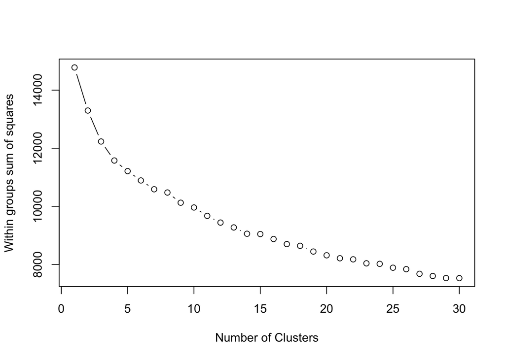

```r
wss <- (nrow(MyData)-1)*sum(apply(MyData,2,var))
for (i in 2:30) wss[i] <- sum(kmeans(MyData,
   centers=i)$withinss)
plot(1:30, wss, type="b", xlab="Number of Clusters",
  ylab="Within groups sum of squares")
```

##### This graph is not necessarily very helpful when it comes to determining the optimal cluster numbers. It appears, that 5 or 15 may appear the elbow points where the graph turns. This method may be easy, however, it will be on the observer to make a determination. In other words, it is not exact, but very helpful.

### The Gap Statistics

##### This compares the “total within intra-cluster variation for different values of K with their expected values under null reference distribution of data. Therefore, the otpimal cluster will be the value that maximize the gap statistics.”<sup>1</sup> This appraoch is more accurate compared to the Elbow Method.

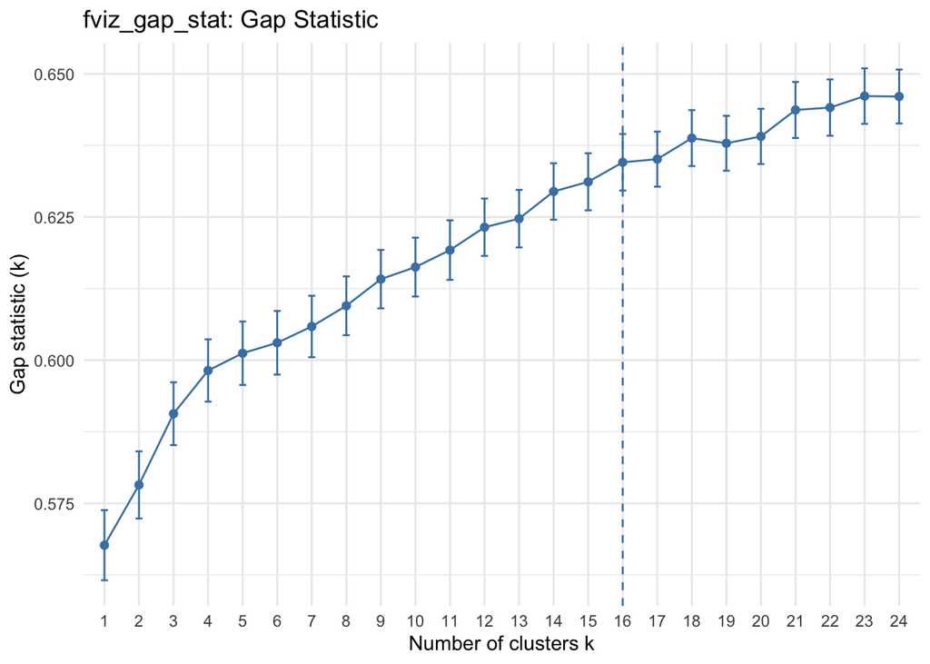

```r
gap_stat <- clusGap(MyData, FUN = kmeans, nstart = 30, K.max = 24, B = 50)
fviz_gap_stat(gap_stat) + theme_minimal() + ggtitle("fviz_gap_stat: Gap Statistic")
```